# Mapping and Plotting

davegoblue

3/10/2020

## Background

This document is to provide some plotting examples for reference.

#### *Example #1: US State and County Maps*

The package usmap contains maps of US states and counties. There is also some associated data available about state and county demographics.

Example code includes:

```r
library(tidyverse)
# Population by county
data(countypop, package="usmap")
# Population by state
data(statepop, package="usmap")
# Poverty rate by county
data(countypov, package="usmap")
# Poverty rate by state
data(statepov, package="usmap")
# Population of largest city by state
data(citypop, package="usmap")
# Location of earthquakes
data(earthquakes, package="usmap")


# Included datasets
countypop
```

```
## # A tibble: 3,142 x 4
##    fips  abbr  county          pop_2015
##    <chr> <chr> <chr>              <dbl>
##  1 01001 AL    Autauga County     55347
##  2 01003 AL    Baldwin County    203709
##  3 01005 AL    Barbour County     26489
##  4 01007 AL    Bibb County        22583
##  5 01009 AL    Blount County      57673
##  6 01011 AL    Bullock County     10696
##  7 01013 AL    Butler County      20154
##  8 01015 AL    Calhoun County    115620
##  9 01017 AL    Chambers County    34123
## 10 01019 AL    Cherokee County    25859
## # ... with 3,132 more rows
```

```r
statepop
```

```
## # A tibble: 51 x 4
##    fips  abbr  full                 pop_2015
##    <chr> <chr> <chr>                   <dbl>
##  1 01    AL    Alabama               4858979
##  2 02    AK    Alaska                 738432
##  3 04    AZ    Arizona               6828065
##  4 05    AR    Arkansas              2978204
##  5 06    CA    California           39144818
##  6 08    CO    Colorado              5456574
##  7 09    CT    Connecticut           3590886
##  8 10    DE    Delaware               945934
##  9 11    DC    District of Columbia   672228
## 10 12    FL    Florida              20271272
## # ... with 41 more rows
```

```r
countypov
```

```
## # A tibble: 3,142 x 4
##    fips  abbr  county          pct_pov_2014
##    <chr> <chr> <chr>                  <dbl>
##  1 01001 AL    Autauga County          13.1
##  2 01003 AL    Baldwin County          13
##  3 01005 AL    Barbour County          25.4
##  4 01007 AL    Bibb County             18.1
##  5 01009 AL    Blount County           17.5
##  6 01011 AL    Bullock County          35.1
##  7 01013 AL    Butler County           25
##  8 01015 AL    Calhoun County          20.5
##  9 01017 AL    Chambers County         21.3
## 10 01019 AL    Cherokee County         18.6
## # ... with 3,132 more rows
```

```r
statepov
```

```
## # A tibble: 51 x 4
##    fips  abbr  full                 pct_pov_2014
##    <chr> <chr> <chr>                       <dbl>
##  1 01    AL    Alabama                      19.2
##  2 02    AK    Alaska                       11.4
##  3 04    AZ    Arizona                      18.2
##  4 05    AR    Arkansas                     18.7
##  5 06    CA    California                   16.4
##  6 08    CO    Colorado                     12.1
##  7 09    CT    Connecticut                  10.8
##  8 10    DE    Delaware                     13
##  9 11    DC    District of Columbia         18.4
## 10 12    FL    Florida                      16.6
## # ... with 41 more rows
```

```r
citypop
```

```
## # A tibble: 51 x 6
##       lon   lat state                abbr  most_populous_city city_pop
##     <dbl> <dbl> <chr>                <chr> <chr>                 <dbl>
##  1  -86.8  33.6 Alabama              AL    Birmingham           212237
##  2 -150.   61.2 Alaska               AK    Anchorage            291826
##  3 -112.   33.4 Arizona              AZ    Phoenix             1445632
##  4  -92.3  34.7 Arkansas             AR    Little Rock          193524
##  5 -118.   34.0 California           CA    Los Angeles         3792621
##  6 -105.   39.8 Colorado             CO    Denver               600158
##  7  -73.2  41.2 Connecticut          CT    Bridgeport           144229
##  8  -75.6  39.8 Delaware             DE    Wilmington            70851
##  9  -77.0  38.9 District of Columbia DC    Washington           693972
## 10  -81.7  30.3 Florida              FL    Jacksonville         880619
## # ... with 41 more rows
```

```r
earthquakes
```

```
## # A tibble: 2,254 x 3
##      lon   lat   mag
##    <dbl> <dbl> <dbl>
##  1 -118.  35.7  2.79
##  2 -118.  36.3  3.1
##  3 -118.  36.2  2.74
##  4 -125.  40.4  2.77
##  5 -118.  35.7  2.59
##  6 -118.  35.7  2.82
##  7 -118.  35.7  2.78
##  8 -124.  40.3  3.42
##  9 -124.  41.7  2.5
## 10 -119.  35.3  2.58
## # ... with 2,244 more rows
```

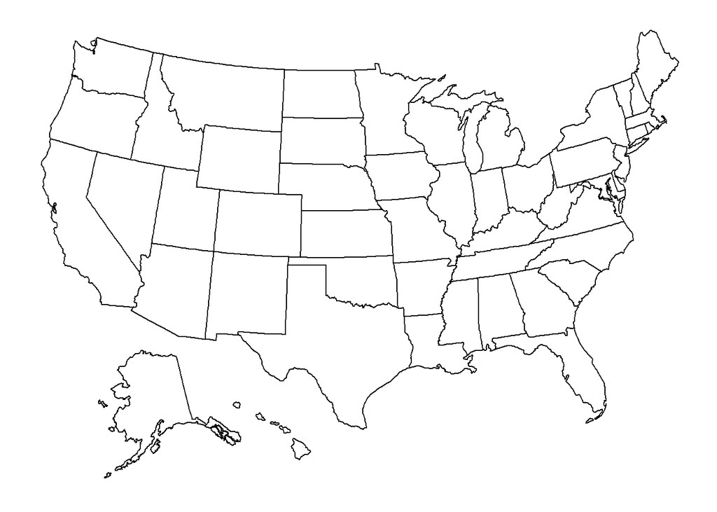

```r
# Basic, empty US maps
usmap::plot_usmap(regions="states")
```

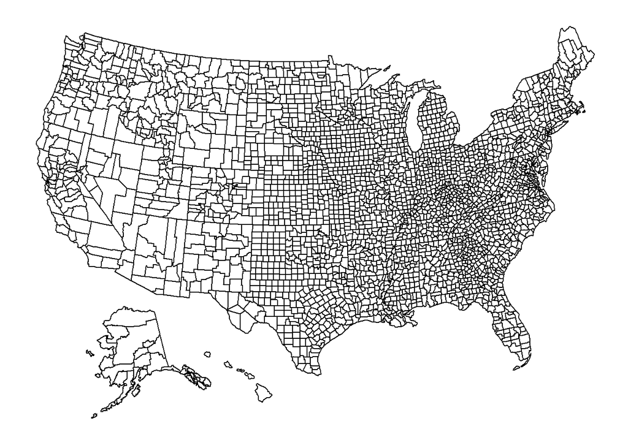

```r
usmap::plot_usmap(regions="counties")
```

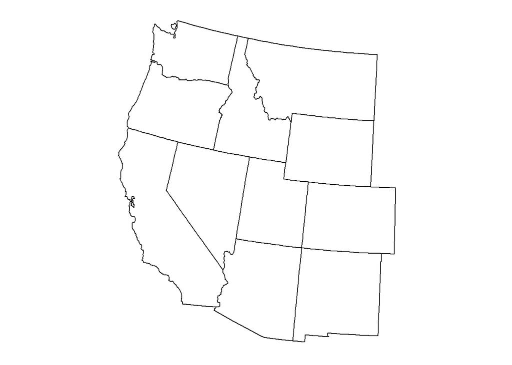

```r
# Basic, empty US maps subsetted to an area
usmap::plot_usmap(regions="states",
                  include=c("WA", "OR", "CA", "NV", "ID", "MT", "WY", "UT", "CO", "AZ", "NM")
                  )
```

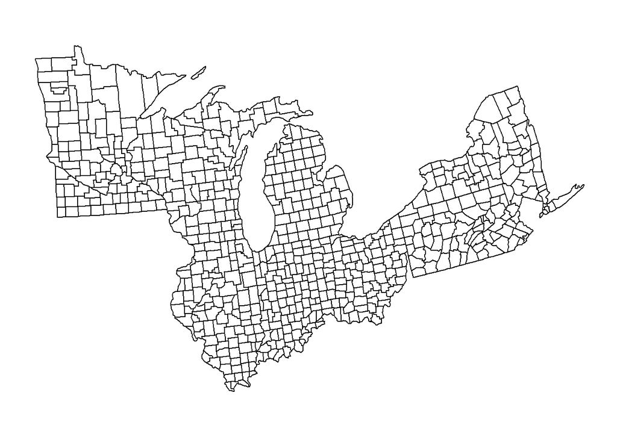

```r
usmap::plot_usmap(regions="counties", include=c("MN", "WI", "MI", "OH", "PA", "NY", "IN", "IL"))
```

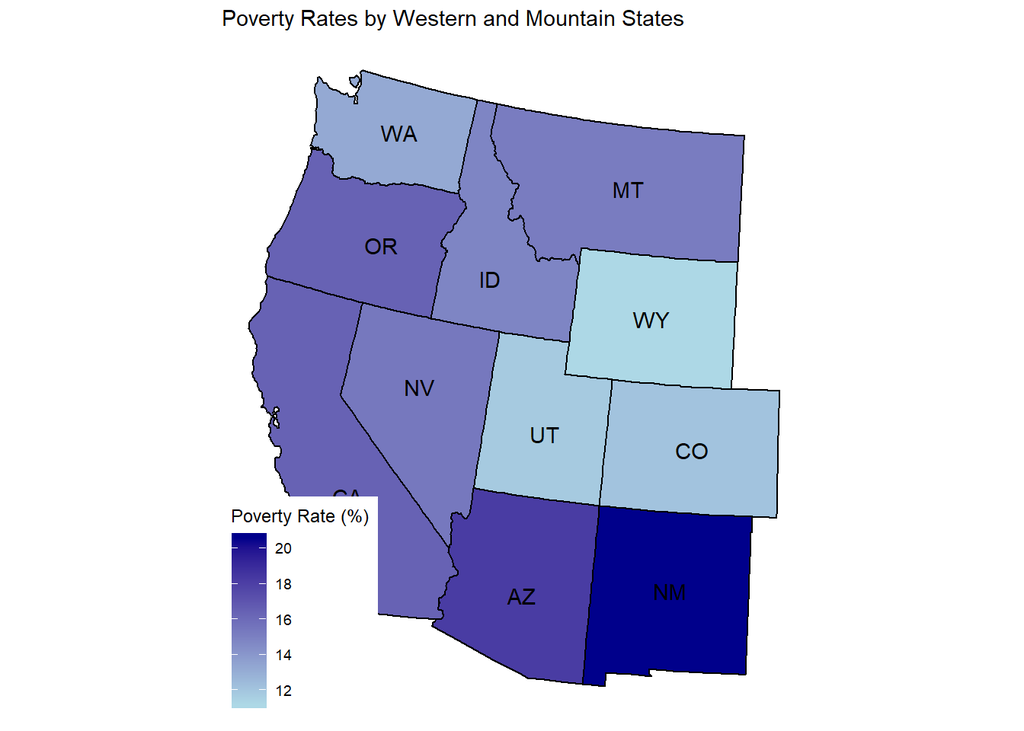

```r
# Basic, subsetted state map with poverty rates included
usmap::plot_usmap(regions="states",
                  include=c("WA", "OR", "CA", "NV", "ID", "MT", "WY", "UT", "CO", "AZ", "NM"),
                  values="pct_pov_2014", data=statepov, labels=TRUE
                  ) +
    scale_fill_continuous(low="lightblue", high="darkblue", "Poverty Rate (%)") +
    labs(title="Poverty Rates by Western and Mountain States")
```

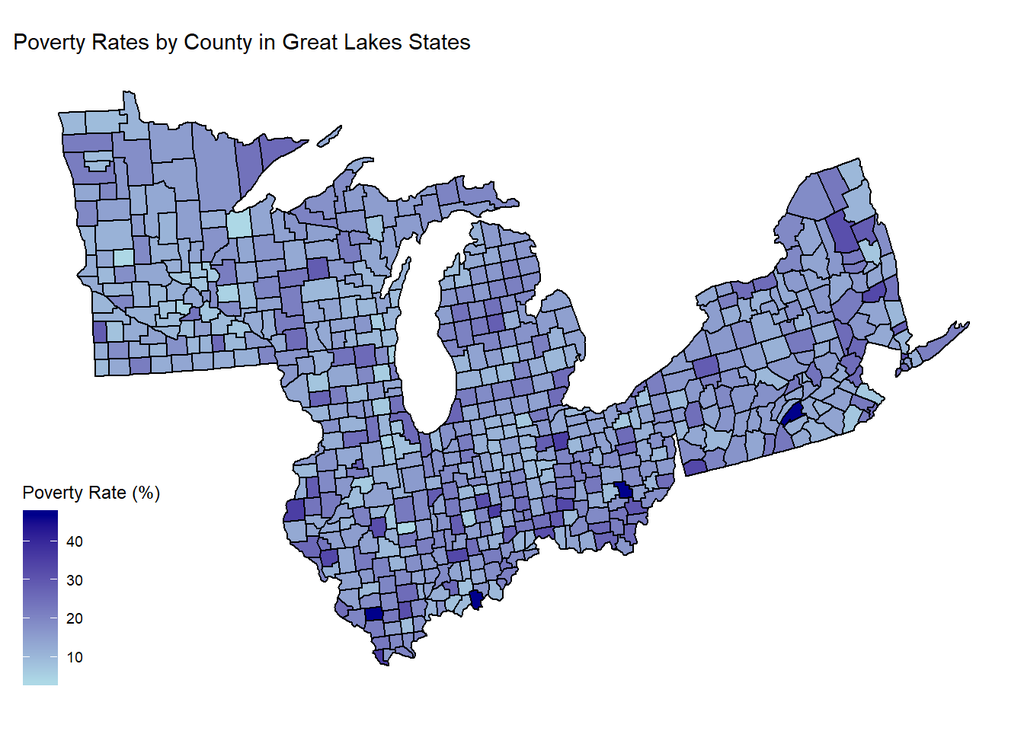

```r
# Basic, subsetted county map with poverty rates included
usmap::plot_usmap(regions="counties", include=c("MN", "WI", "MI", "OH", "PA", "NY", "IN", "IL"),
                  values="pct_pov_2014", data=countypov, labels=FALSE
                  ) +
    scale_fill_continuous(low="lightblue", high="darkblue", "Poverty Rate (%)") +
    labs(title="Poverty Rates by County in Great Lakes States")
```

#### *Example #2: Converting and adding lat/lon data*

The latitude and longitude data can be converted to a form suitable for usmap by using the usmap_transform function.

Example code includes:

```r
# Transform the earthquakes data
trQuakes <- usmap::usmap_transform(earthquakes)
str(trQuakes)
```

```
## 'data.frame':    2254 obs. of  5 variables:
##  $ lon  : num  -118 -118 -118 -125 -118 ...
##  $ lat  : num  35.7 36.3 36.2 40.4 35.7 ...
##  $ mag  : num  2.79 3.1 2.74 2.77 2.59 2.82 2.78 3.42 2.5 2.58 ...
##  $ lon.1: num  -1575319 -1632293 -1595342 -2065325 -1574008 ...
##  $ lat.1: num  -872720 -785212 -811800 -197614 -867723 ...
```

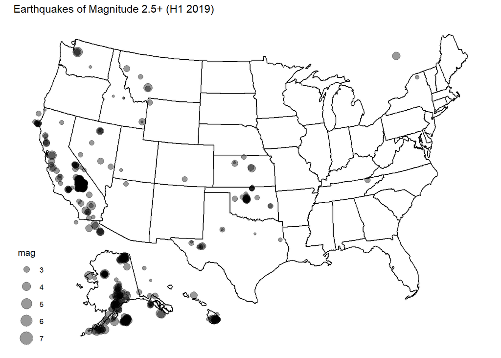

```r
# Add as a layer to the state map
usmap::plot_usmap(regions="states") +
    geom_point(data=trQuakes, aes(x=lon.1, y=lat.1, size=mag), alpha=0.4) +
    labs(title="Earthquakes of Magnitude 2.5+ (H1 2019)")
```

```r
# Transform the largest city data
trCity <- usmap::usmap_transform(citypop)
str(trCity)
```

```
## 'data.frame':    51 obs. of  8 variables:
##  $ lon               : num  -86.8 -112.1 -92.3 -118.2 -104.9 ...
##  $ lat               : num  33.6 33.5 34.7 34 39.8 ...
##  $ state             : chr  "Alabama" "Arizona" "Arkansas" "California" ...
##  $ abbr              : chr  "AL" "AZ" "AR" "CA" ...
##  $ most_populous_city: chr  "Birmingham" "Phoenix" "Little Rock" "Los Angeles" ...
##  $ city_pop          : num  212237 1445632 193524 3792621 600158 ...
##  $ lon.1             : num  1220905 -1120927 702478 -1673156 -417275 ...
##  $ lat.1             : num  -1165156 -1202575 -1107534 -1034842 -570173 ...
```

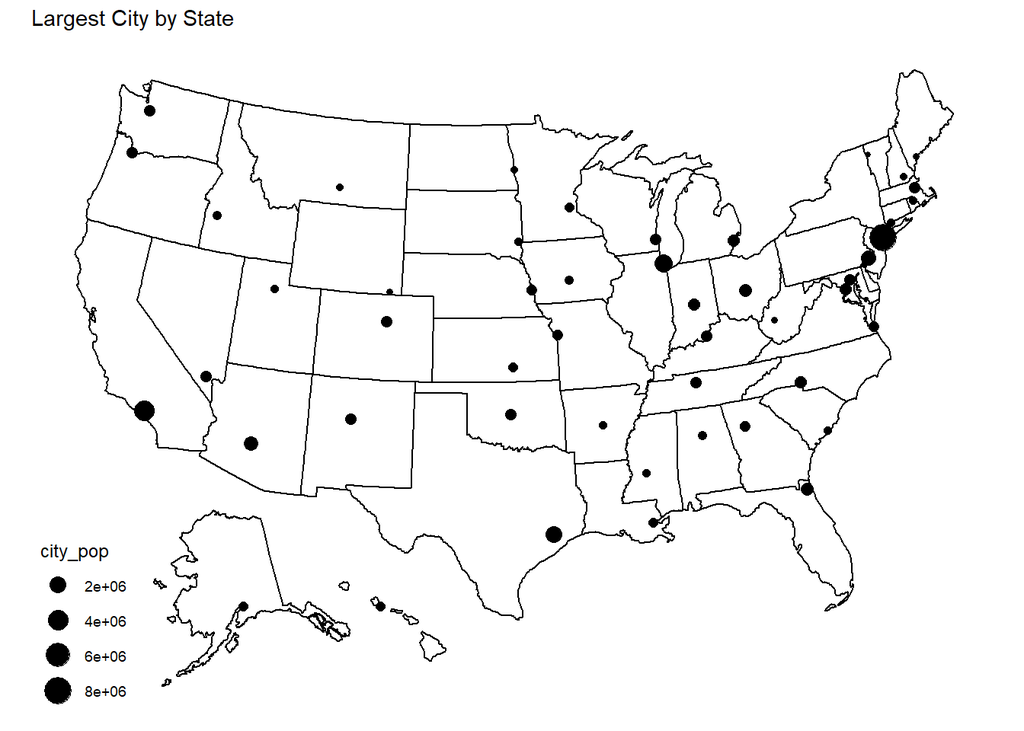

```r
# Add as a layer to the state map
usmap::plot_usmap(regions="states") +
    geom_point(data=trCity, aes(x=lon.1, y=lat.1, size=city_pop)) +
    labs(title="Largest City by State")
```

#### *Example #3: Filtering and coloring by region*

The census region definitions are included, and can be used to filter or color the maps.

Example code includes:

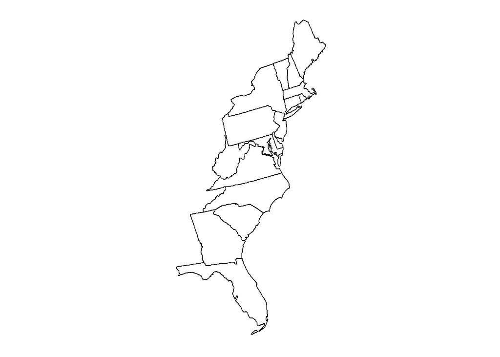

```r
# Filter the map to include only new_england, mid_atlantic, and south_atlantic
usmap::plot_usmap(regions="states",
                  include=c(usmap::.new_england, usmap::.mid_atlantic, usmap::.south_atlantic)
                  )
```

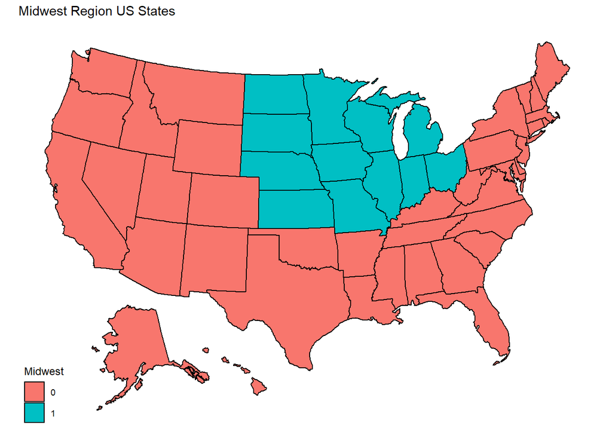

```r
# Create regions data for US states
regionData <- usmap::statepop %>%
    mutate(region=as.factor(ifelse(abbr %in% usmap::.midwest_region, 1, 0)))
usmap::plot_usmap(regions="states", data=regionData, values="region") +
    scale_fill_discrete("Midwest") +
    labs(title="Midwest Region US States")
```

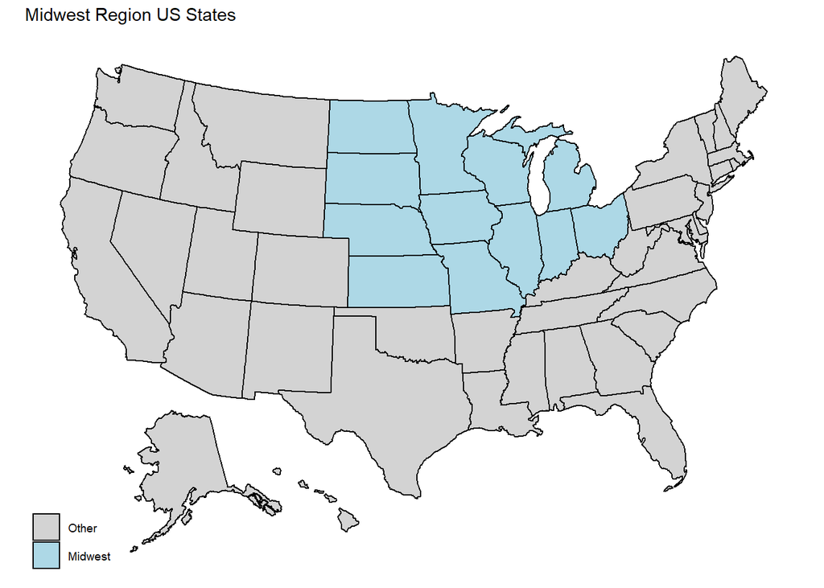

```r
# Enhanced Coloring and Labelling
usmap::plot_usmap(regions="states", data=regionData, values="region") +
    scale_fill_manual(values=c("lightgray", "lightblue"), "", labels=c("Other", "Midwest")) +
    labs(title="Midwest Region US States")
```

#### *Example #4: Labelling geographies*

Since usmap is built on ggplot2, the standard techniques from ggplot2 can be used to enhance the geography labelling. Further, centroids for the geographies are available in loadable files.

Example code includes:

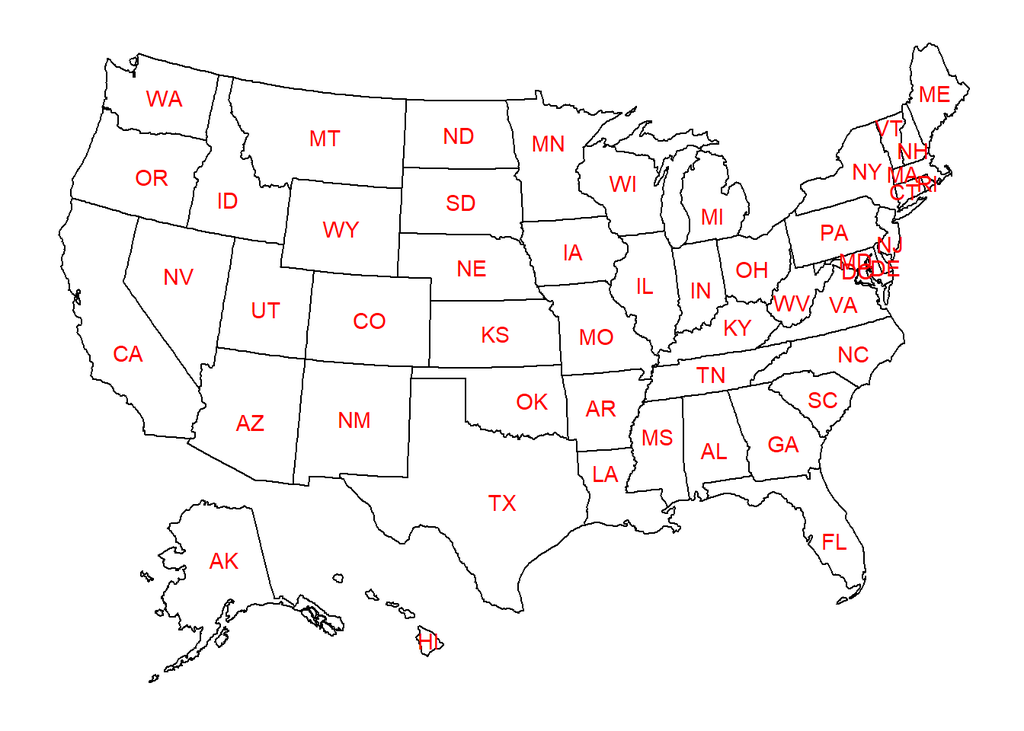

```r
# Base state map labelled with defaults
usmap::plot_usmap(regions="states", labels=TRUE, label_color="red")
```

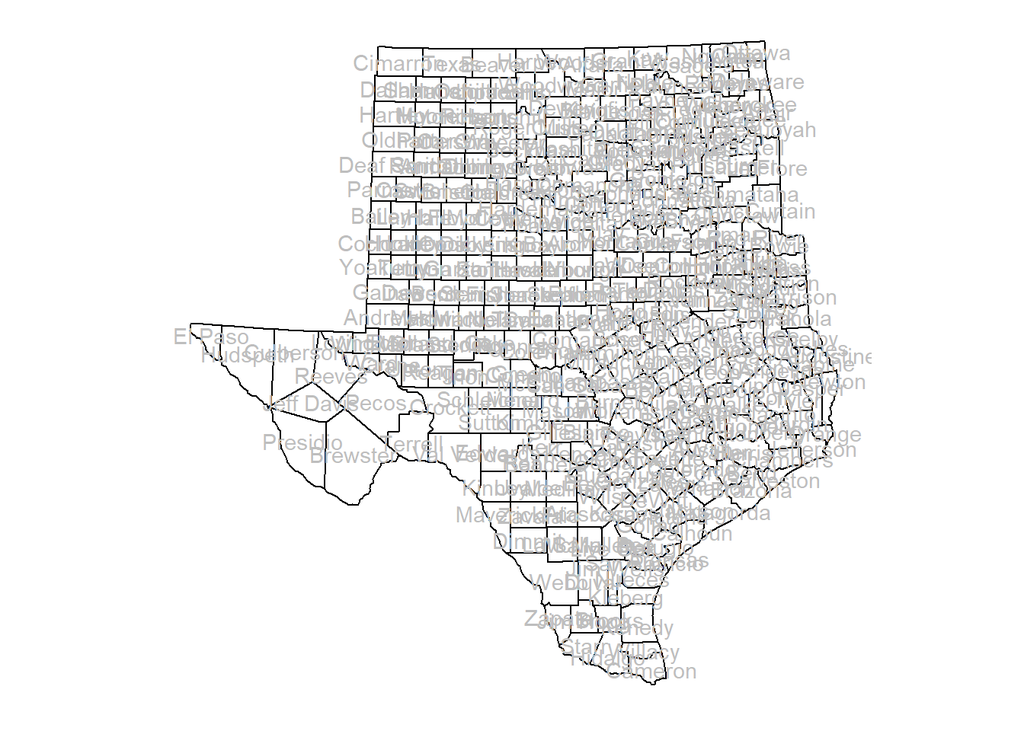

```r
# Base county map labelled with defaults
usmap::plot_usmap(regions="counties", include=c("TX", "OK"), labels=TRUE, label_color="grey")
```

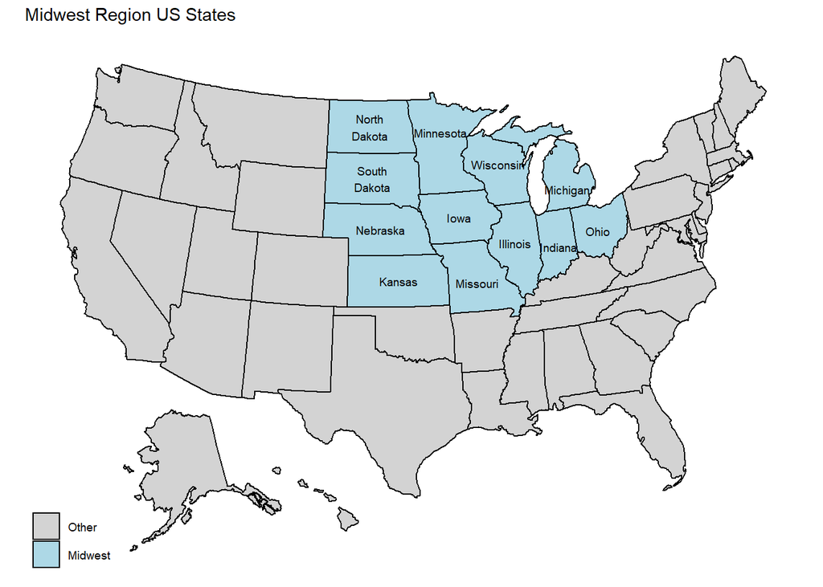

```r
# Load state centroid data
stCenter <- utils::read.csv(system.file("extdata",
                                        paste0("us_", "states", "_centroids.csv"), package = "usmap"
                                        ),
                            colClasses = c(rep("numeric", 2), rep("character", 3)), stringsAsFactors = FALSE
                            )

# Load county centroid data
ctCenter <- utils::read.csv(system.file("extdata",
                                        paste0("us_", "counties", "_centroids.csv"), package = "usmap"
                                        ),
                            colClasses = c(rep("numeric", 2), rep("character", 4)), stringsAsFactors = FALSE
                            )

# Add state labels using geom_text
regionData <- usmap::statepop %>%
    mutate(region=as.factor(ifelse(abbr %in% usmap::.midwest_region, 1, 0))) %>%
    left_join(stCenter %>% select(x, y, full, fips) %>% rename(fname=full)) %>%
    mutate(fname=ifelse(fname=="District of Columbia", "DC", str_replace_all(fname, " ", "\n")))
usmap::plot_usmap(regions="states", data=regionData[, c("fips", "region")], values="region") +
    scale_fill_manual(values=c("lightgray", "lightblue"), "", labels=c("Other", "Midwest")) +
    labs(title="Midwest Region US States") +
    geom_text(data=filter(regionData, region==1), aes(x=x, y=y, label=fname), size=2.5)
```

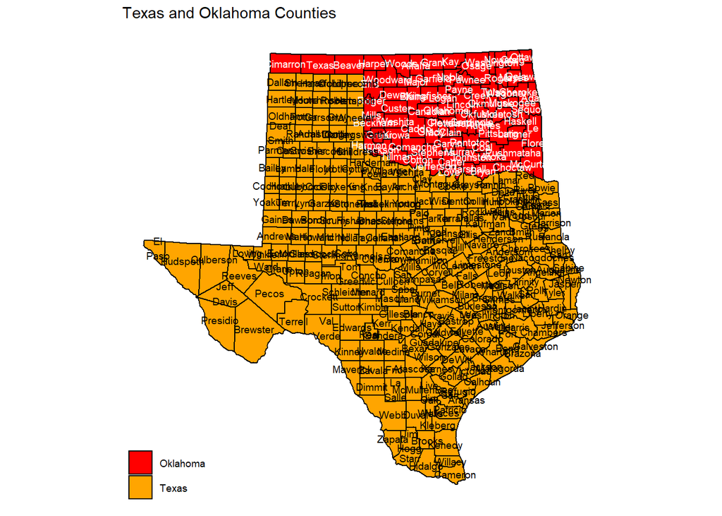

```r
# Add county labels using geom_text
regionData <- usmap::countypop %>%
    mutate(region=as.factor(case_when(abbr=="OK" ~ 1, abbr=="TX" ~ 2, TRUE ~ 0))) %>%
    left_join(ctCenter %>% select(x, y, county, fips) %>% rename(cname=county)) %>%
    mutate(cname=str_replace_all(str_replace(cname, " County", ""), " ", "\n"))
usmap::plot_usmap(regions="counties", include=c("TX", "OK"),
                  data=regionData[, c("fips", "region")], values="region") +
    scale_fill_manual(values=c("red", "orange"), "", labels=c("Oklahoma", "Texas")) +
    labs(title="Texas and Oklahoma Counties") +
    geom_text(data=filter(regionData, abbr %in% c("TX", "OK")),
              aes(x=x, y=y, label=cname), size=2.5,
              color=ifelse(pull(filter(regionData, abbr %in% c("TX", "OK")), abbr)=="OK", "white", "black")
              )
```

#### *Example #5: Adding population centers*

Separate data exists for key population centers, which can be loaded and then added to maps.

Example code includes:

```r
# Transform the largest city data
str(maps::us.cities)
```

```
## 'data.frame':    1005 obs. of  6 variables:
##  $ name       : chr  "Abilene TX" "Akron OH" "Alameda CA" "Albany GA" ...
##  $ country.etc: chr  "TX" "OH" "CA" "GA" ...
##  $ pop        : int  113888 206634 70069 75510 93576 45535 494962 44933 127159 88857 ...
##  $ lat        : num  32.5 41.1 37.8 31.6 42.7 ...
##  $ long       : num  -99.7 -81.5 -122.3 -84.2 -73.8 ...
##  $ capital    : int  0 0 0 0 2 0 0 0 0 0 ...
```

```r
trCity <- usmap::usmap_transform(select(maps::us.cities, long, lat, everything())) %>%
    mutate(useName=str_replace_all(str_sub(name, 1, -4), " ", "\n"))
str(trCity)
```

```
## 'data.frame':    1005 obs. of  9 variables:
##  $ long       : num  -99.7 -81.5 -122.3 -84.2 -73.8 ...
##  $ lat        : num  32.5 41.1 37.8 31.6 42.7 ...
##  $ name       : chr  "Abilene TX" "Akron OH" "Alameda CA" "Albany GA" ...
##  $ country.etc: chr  "TX" "OH" "CA" "GA" ...
##  $ pop        : int  113888 206634 70069 75510 93576 45535 494962 44933 127159 88857 ...
##  $ capital    : int  0 0 0 0 2 0 0 0 0 0 ...
##  $ long.1     : num  24544 1533716 -1931842 1498524 2096820 ...
##  $ lat.1      : num  -1392670 -262400 -543195 -1350290 82431 ...
##  $ useName    : chr  "Abilene" "Akron" "Alameda" "Albany" ...
```

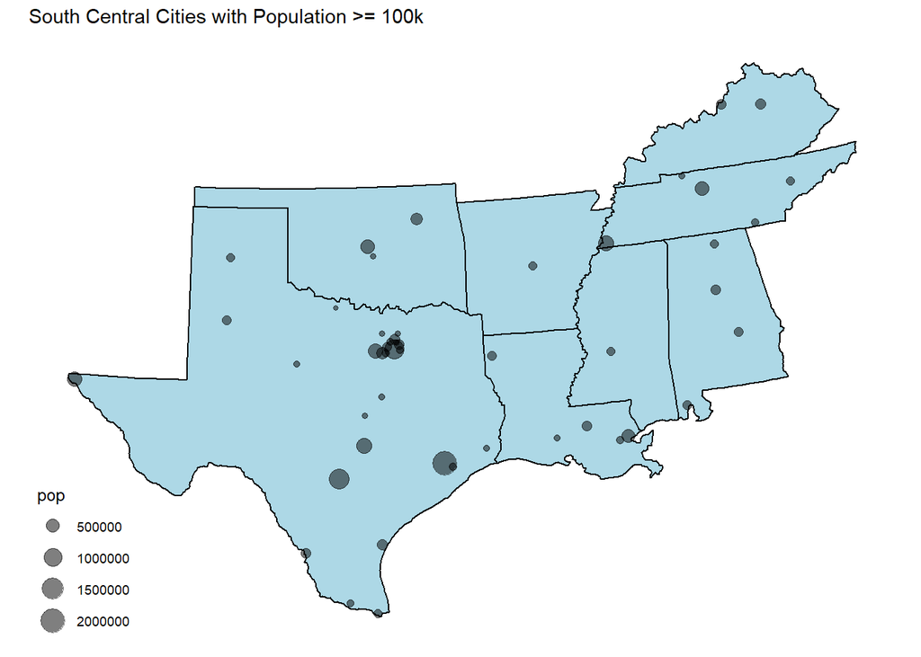

```r
# Define a key region for plotting
rgnPlot <- c(usmap::.west_south_central, usmap::.east_south_central)
popFilter <- 100000

# Add cities as a layer to the state map
usmap::plot_usmap(regions="states", include=rgnPlot, fill="lightblue") +
    labs(title=paste0("South Central Cities with Population >= ", popFilter/1000, "k")) +
    geom_point(data=filter(trCity, pop >= popFilter, country.etc %in% rgnPlot),
               aes(x=long.1, y=lat.1, size=pop), alpha=0.5
               )
```

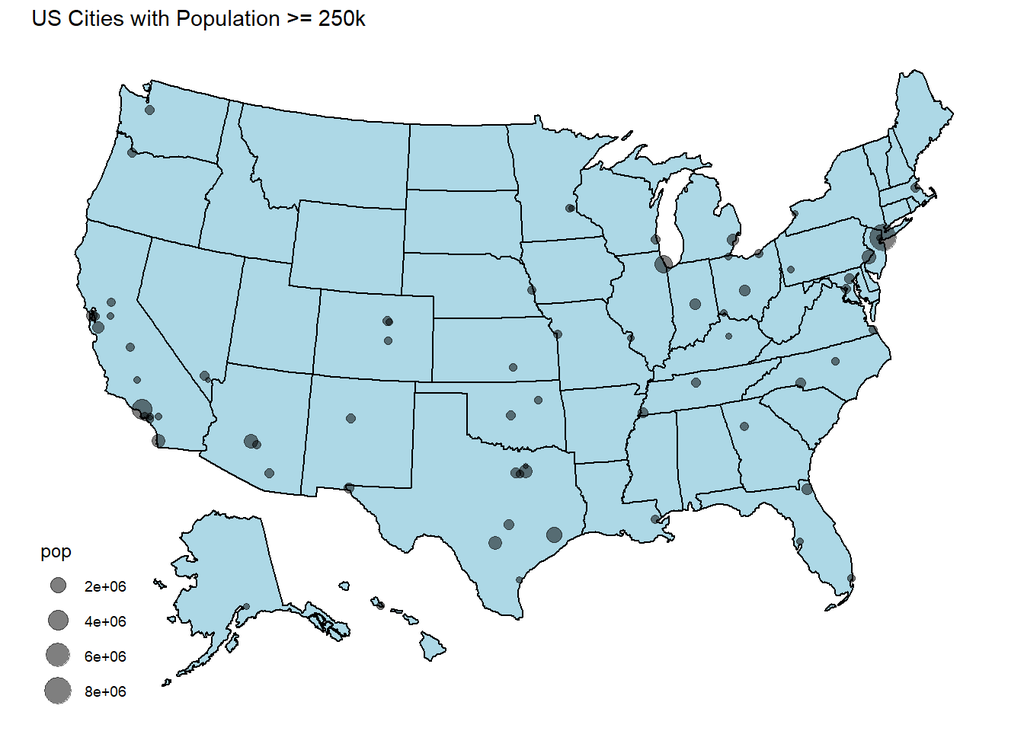

```r
# Plot the full nation for cities of 250k +
rgnPlot <- c(usmap::.midwest_region, usmap::.northeast_region,
             usmap::.south_region, usmap::.west_region
             )
popFilter <- 250000

# Add cities as a layer to the state map
usmap::plot_usmap(regions="states", include=rgnPlot, fill="lightblue") +
    labs(title=paste0("US Cities with Population >= ", popFilter/1000, "k")) +
    geom_point(data=filter(trCity, pop >= popFilter, country.etc %in% rgnPlot),
               aes(x=long.1, y=lat.1, size=pop), alpha=0.5
               )
```

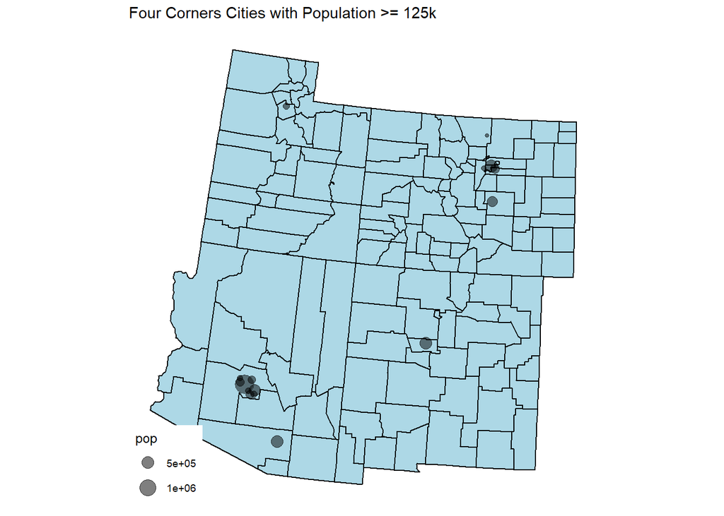

```r
# Plot cities by name for the Four Corners region
rgnPlot <- c("UT", "CO", "NM", "AZ")
popFilter <- 125000

# Add cities as a layer to the state map (points)
usmap::plot_usmap(regions="counties", include=rgnPlot, fill="lightblue") +
    labs(title=paste0("Four Corners Cities with Population >= ", popFilter/1000, "k")) +
    geom_point(data=filter(trCity, pop >= popFilter, country.etc %in% rgnPlot),
               aes(x=long.1, y=lat.1, size=pop), alpha=0.5
               )
```

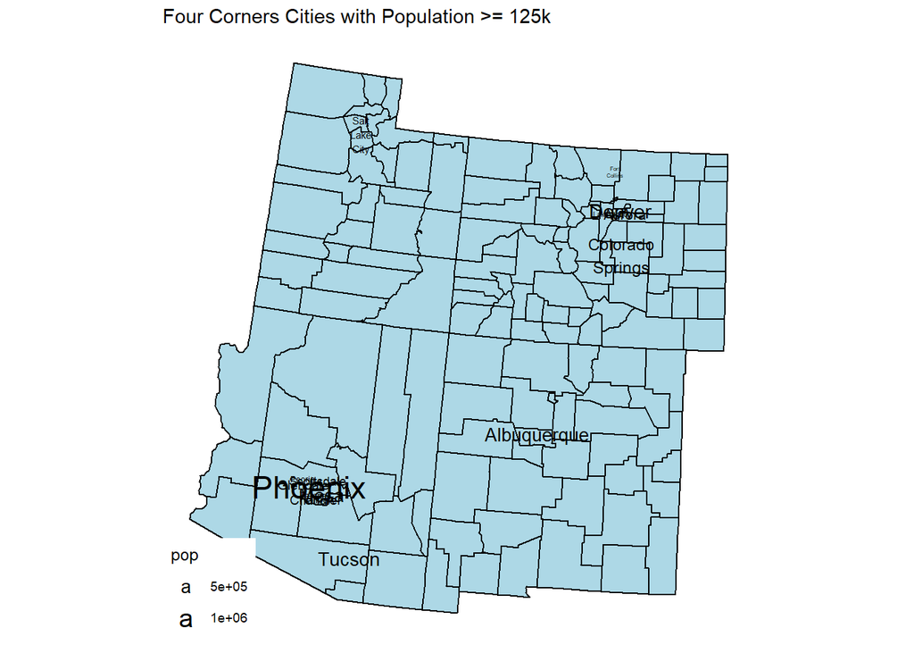

```r
# Add cities as a layer to the state map (text)
usmap::plot_usmap(regions="counties", include=rgnPlot, fill="lightblue") +
    labs(title=paste0("Four Corners Cities with Population >= ", popFilter/1000, "k")) +
    geom_text(data=filter(trCity, pop >= popFilter, country.etc %in% rgnPlot),
               aes(x=long.1, y=lat.1, size=pop, label=useName)
               )
```

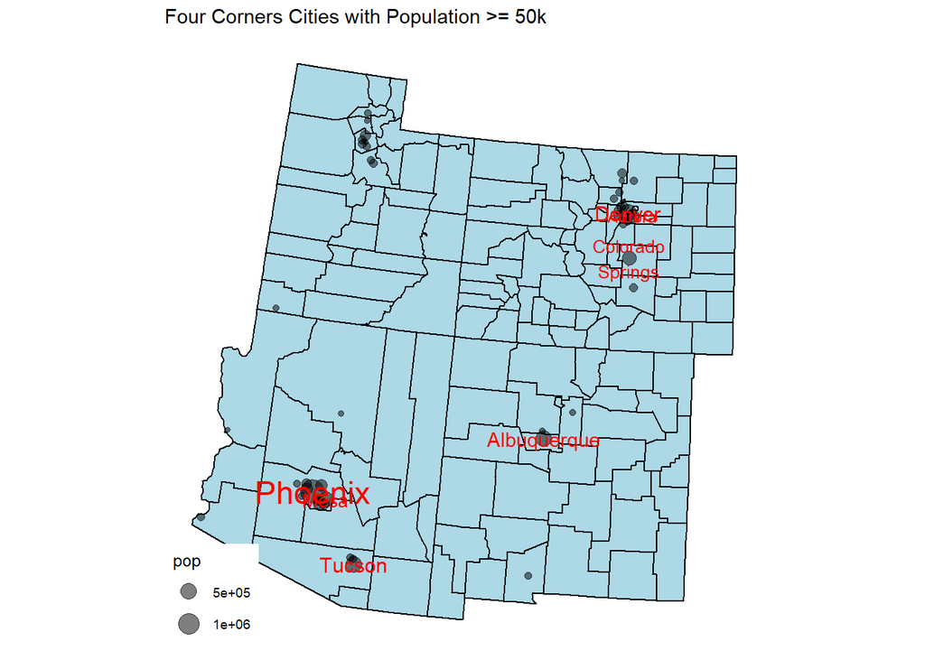

```r
popFilter <- 50000
popFilter2 <- 250000

# Add cities as a layer to the state map (points and text)
usmap::plot_usmap(regions="counties", include=rgnPlot, fill="lightblue") +
    labs(title=paste0("Four Corners Cities with Population >= ", popFilter/1000, "k")) +
    geom_point(data=filter(trCity, pop >= popFilter, country.etc %in% rgnPlot),
               aes(x=long.1, y=lat.1, size=pop), alpha=0.5
               ) +
    geom_text(data=filter(trCity, pop >= popFilter2, country.etc %in% rgnPlot),
               aes(x=long.1, y=lat.1, size=pop, label=useName), color="red", show.legend=FALSE
               )
```

#### *Example #6: Custom coloring geographies*

Using scale_fill_manual(), custom colors can be created by geography.

Example code includes:

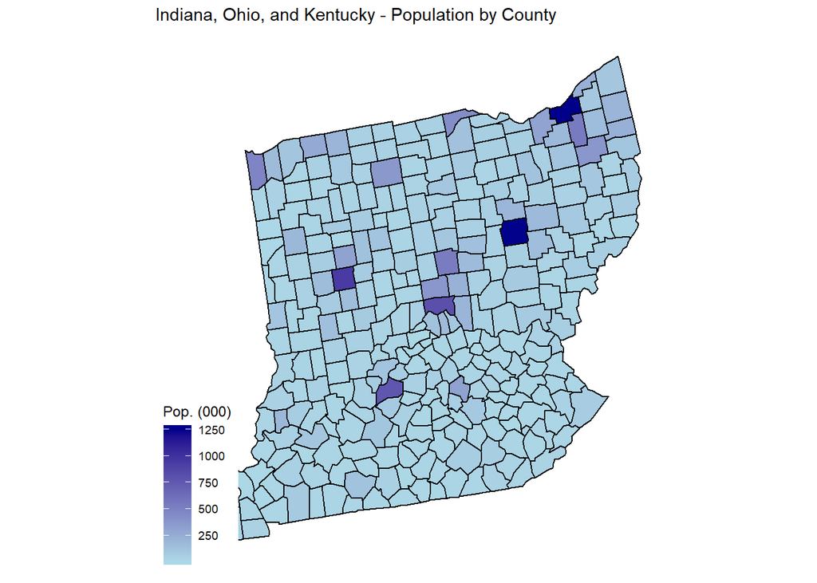

```r
# Basic county population map with continuous colors
usmap::countypop %>%
    filter(abbr %in% c("OH", "IN", "KY")) %>%
    mutate(pop=pop_2015/1000, name=str_replace(str_replace(county, " County", ""), " ", "\n")) %>%
    usmap::plot_usmap(regions="counties", include=c("OH", "IN", "KY"), data=., values="pop") +
    scale_fill_continuous(low="lightblue", high="darkblue", "Pop. (000)") +
    labs(title="Indiana, Ohio, and Kentucky - Population by County")
```

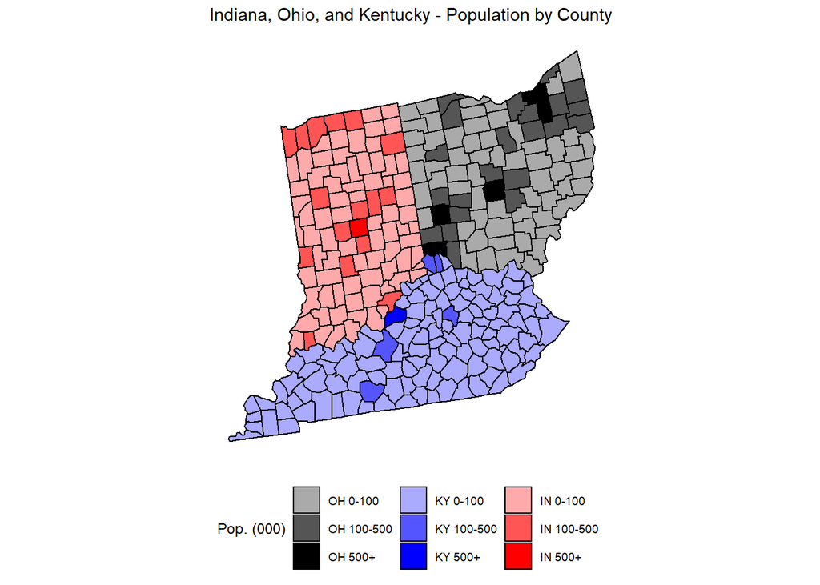

```r
# Custom county population map with colors - red for Indiana, blue for Kentucky, grey for Ohio
popBucket <- c(0, 100, 500)
popLabels <- sapply(1:(length(popBucket)-1), FUN=function(x){paste0(popBucket[x], "-", popBucket[x+1])})
popLabels <- c(popLabels, paste0(popBucket[length(popBucket)], "+"))
guideLabels <- paste(rep(c("OH", "KY", "IN"), each=3), popLabels)

usmap::countypop %>%
    filter(abbr %in% c("OH", "KY", "IN")) %>%
    mutate(pop=pop_2015/1000, name=str_replace(str_replace(county, " County", ""), " ", "\n"),
           pBucket=findInterval(pop, popBucket),
           pColor=rgb(abbr=="IN", 0, abbr=="KY", pBucket/length(popBucket))
           ) %>%
    usmap::plot_usmap(regions="counties", include=c("OH", "IN", "KY"), data=., values="pColor") +
    scale_fill_identity(guide="legend", "Pop. (000)", labels=guideLabels) +
    labs(title="Indiana, Ohio, and Kentucky - Population by County") +
    theme(legend.position = "bottom") +
    guides(fill=guide_legend(nrow=3))
```

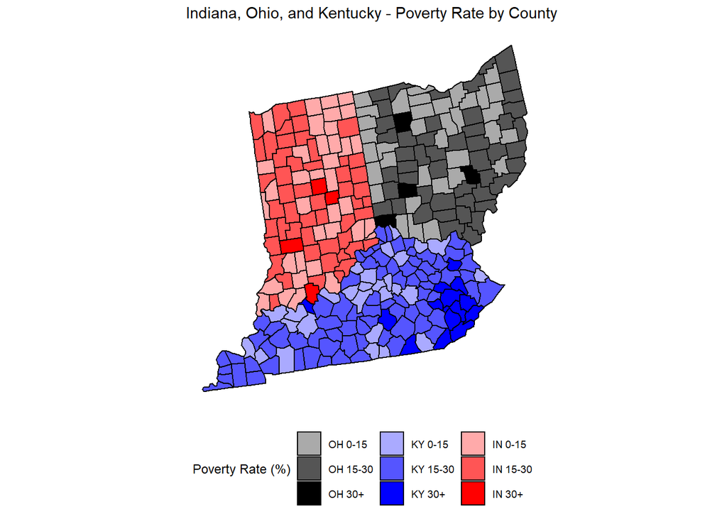

```r
# Custom county poverty rate map with colors - red for Indiana, blue for Kentucky, grey for Ohio
povBucket <- c(0, 15, 30)
povLabels <- sapply(1:(length(povBucket)-1), FUN=function(x){paste0(povBucket[x], "-", povBucket[x+1])})
povLabels <- c(povLabels, paste0(povBucket[length(povBucket)], "+"))
guideLabels <- paste(rep(c("OH", "KY", "IN"), each=3), povLabels)

usmap::countypov %>%
    filter(abbr %in% c("OH", "KY", "IN")) %>%
    mutate(name=str_replace(str_replace(county, " County", ""), " ", "\n"),
           pBucket=findInterval(pct_pov_2014, povBucket),
           pColor=rgb(abbr=="IN", 0, abbr=="KY", pBucket/length(povBucket))
           ) %>%
    usmap::plot_usmap(regions="counties", include=c("OH", "IN", "KY"), data=., values="pColor") +
    scale_fill_identity(guide="legend", "Poverty Rate (%)", labels=guideLabels) +
    labs(title="Indiana, Ohio, and Kentucky - Poverty Rate by County") +
    theme(legend.position = "bottom") +
    guides(fill=guide_legend(nrow=3))
```

#### *Example #7: Custom labeling of key geographies*

The above techniques can be combined for custom labeling of key geographies.

Example code includes:

```r
# Basic state population data
stateData <- usmap::statepop %>%
    mutate(pop=round(pop_2015/1000000, 1),
           name=ifelse(full=="District of Columbia", "DC", str_replace(full, " ", "\n")),
           lab=paste0(abbr, "\n(", pop, ")\n")
           )

# Load state centroid data
stCenter <- utils::read.csv(system.file("extdata",
                                        paste0("us_", "states", "_centroids.csv"), package = "usmap"
                                        ),
                            colClasses = c(rep("numeric", 2), rep("character", 3)), stringsAsFactors = FALSE
                            )

# Grab centroids for top 5 states
top5State <- stateData %>%
    top_n(5, pop) %>%
    left_join(select(stCenter, x, y, fips))
```

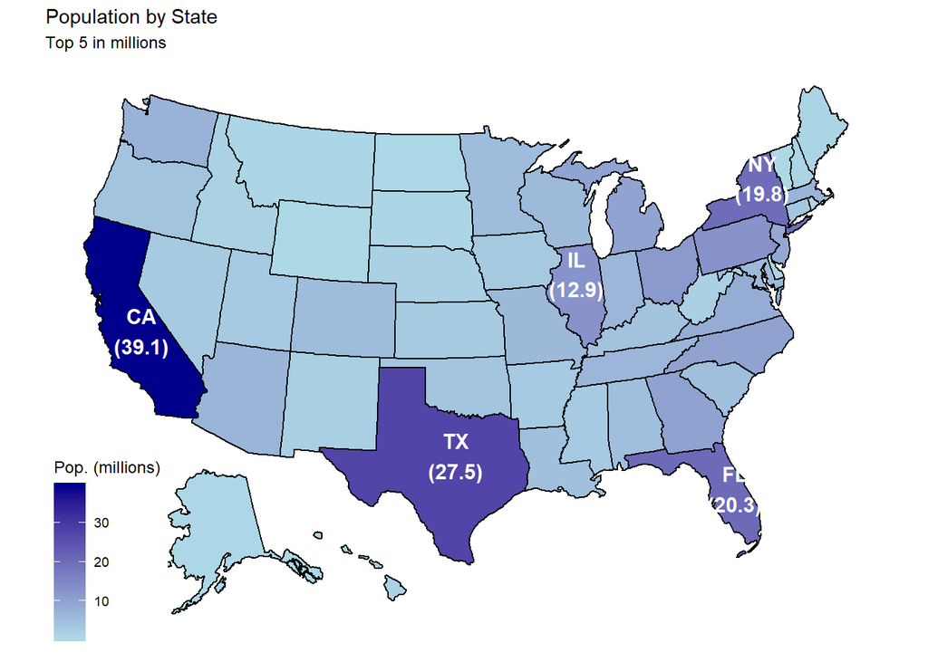

```r
# Plot state population with continuous colors and custom labels
stateData %>%
    usmap::plot_usmap(regions="states", data=., values="pop") +
    scale_fill_continuous(low="lightblue", high="darkblue", "Pop. (millions)") +
    labs(title="Population by State", subtitle="Top 5 in millions") +
    geom_text(data=top5State, aes(x=x, y=y, label=lab), color="white", size=4, fontface="bold")
```

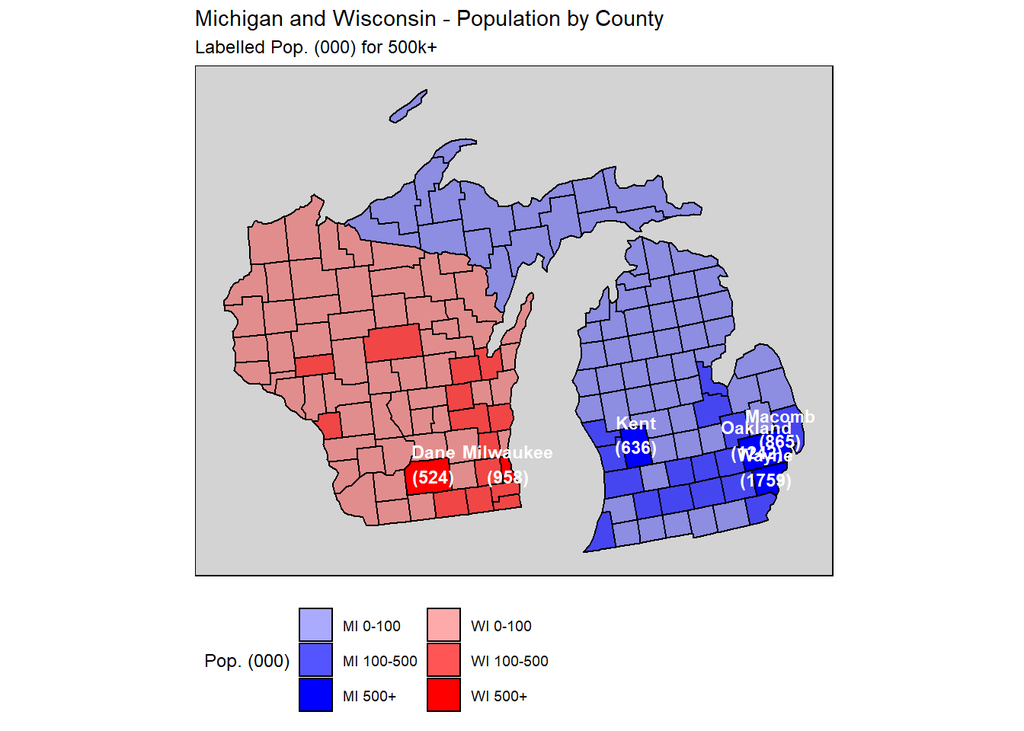

```r
# Load county centroid data
ctCenter <- utils::read.csv(system.file("extdata",
                                        paste0("us_", "counties", "_centroids.csv"), package = "usmap"
                                        ),
                            colClasses = c(rep("numeric", 2), rep("character", 4)), stringsAsFactors = FALSE
                            )

# Custom county population map with colors - red for Wisconsin, blue for Michigan
popBucket <- c(0, 100, 500)
popLabels <- sapply(1:(length(popBucket)-1), FUN=function(x){paste0(popBucket[x], "-", popBucket[x+1])})
popLabels <- c(popLabels, paste0(popBucket[length(popBucket)], "+"))
guideLabels <- paste(rep(c("MI", "WI"), each=3), popLabels)

# Grab county data for counties exceeding the top popBucket
ctyData <- usmap::countypop %>%
    filter(abbr %in% c("MI", "WI")) %>%
    mutate(pop=round(pop_2015/1000, 0),
           name=str_replace(str_replace(county, " County", ""), " ", "\n"),
           lab=paste0(name, "\n(", pop, ")\n")
           )

topCounty <- ctyData %>%
    filter(pop >= max(popBucket)) %>%
    left_join(select(ctCenter, x, y, fips))
# Create county population map
usmap::countypop %>%
    filter(abbr %in% c("MI", "WI")) %>%
    mutate(pop=pop_2015/1000, name=str_replace(str_replace(county, " County", ""), " ", "\n"),
           pBucket=findInterval(pop, popBucket),
           pColor=rgb(abbr=="WI", 0, abbr=="MI", pBucket/length(popBucket))
           ) %>%
    usmap::plot_usmap(regions="counties", include=c("WI", "MI"), data=., values="pColor") +
    scale_fill_identity(guide="legend", "Pop. (000)", labels=guideLabels) +
    geom_text(data=topCounty, aes(x=x, y=y, label=lab), size=3, fontface="bold", color="white") +
    labs(title="Michigan and Wisconsin - Population by County", subtitle="Labelled Pop. (000) for 500k+") +
    theme(legend.position = "bottom") +
    guides(fill=guide_legend(nrow=3)) +
    theme(panel.background=element_rect(color="black", fill="lightgrey"))
```

#### *Example #8: Plotting Weather Data (Temperatures and Dew Points)*

The ggridges package has weather data for Lincoln, NE in the data file ‘lincoln_weather’. The data are captured once per day for 366 days of 2016. Simple plots can be made of the average temperatures and dew points.

Example code includes:

```r
data(lincoln_weather, package="ggridges")
str(lincoln_weather, give.attr=FALSE)
```

```
## Classes 'tbl_df', 'tbl' and 'data.frame':    366 obs. of  24 variables:
##  $ CST                         : chr  "2016-1-1" "2016-1-2" "2016-1-3" "2016-1-4" ...
##  $ Max Temperature [F]         : int  37 41 37 30 38 34 33 28 22 31 ...
##  $ Mean Temperature [F]        : int  24 23 23 17 29 33 30 25 9 11 ...
##  $ Min Temperature [F]         : int  11 5 8 4 19 32 27 22 -4 -9 ...
##  $ Max Dew Point [F]           : int  19 22 23 24 29 33 32 25 17 20 ...
##  $ Mean Dew Point [F]          : int  13 14 15 13 25 32 30 22 4 5 ...
##  $ Min Dewpoint [F]            : int  8 4 8 2 19 29 25 18 -8 -13 ...
##  $ Max Humidity                : int  88 100 92 92 96 100 100 92 87 87 ...
##  $ Mean Humidity               : int  68 72 73 82 83 91 96 85 77 75 ...
##  $ Min Humidity                : int  47 44 54 72 70 82 92 78 67 63 ...
##  $ Max Sea Level Pressure [In] : num  30.5 30.4 30.5 30.5 30.2 ...
##  $ Mean Sea Level Pressure [In]: num  30.4 30.3 30.4 30.4 30.1 ...
##  $ Min Sea Level Pressure [In] : num  30.3 30.2 30.3 30.2 30 ...
##  $ Max Visibility [Miles]      : int  10 10 10 10 10 10 9 10 10 10 ...
##  $ Mean Visibility [Miles]     : int  10 10 10 9 8 4 3 6 9 10 ...
##  $ Min Visibility [Miles]      : int  10 10 10 6 5 0 0 2 5 10 ...
##  $ Max Wind Speed [MPH]        : int  20 15 13 17 22 16 16 25 25 10 ...
##  $ Mean Wind Speed[MPH]        : int  9 6 5 7 13 7 7 16 14 5 ...
##  $ Max Gust Speed [MPH]        : int  23 18 14 23 28 21 21 32 28 12 ...
##  $ Precipitation [In]          : chr  "0" "0" "0" "0" ...
##  $ CloudCover                  : int  0 0 0 1 4 8 8 8 5 0 ...
##  $ Events                      : chr  NA NA NA NA ...
##  $ WindDir [Degrees]           : int  280 312 330 155 178 167 7 338 340 268 ...
##  $ Month                       : Factor w/ 12 levels "December","November",..: 12 12 12 12 12 12 12 12 12 12 ...
```

```r
# Extract temperature and dew point data
tdData <- lincoln_weather %>%
    select(CST, maxT=`Max Temperature [F]`, minT=`Min Temperature [F]`, meanT=`Mean Temperature [F]`,
           maxD=`Max Dew Point [F]`, minD=`Min Dewpoint [F]`, meanD=`Mean Dew Point [F]`
           ) %>%
    mutate(date=as.Date(CST))
str(tdData)
```

```
## Classes 'tbl_df', 'tbl' and 'data.frame':    366 obs. of  8 variables:
##  $ CST  : chr  "2016-1-1" "2016-1-2" "2016-1-3" "2016-1-4" ...
##  $ maxT : int  37 41 37 30 38 34 33 28 22 31 ...
##  $ minT : int  11 5 8 4 19 32 27 22 -4 -9 ...
##  $ meanT: int  24 23 23 17 29 33 30 25 9 11 ...
##  $ maxD : int  19 22 23 24 29 33 32 25 17 20 ...
##  $ minD : int  8 4 8 2 19 29 25 18 -8 -13 ...
##  $ meanD: int  13 14 15 13 25 32 30 22 4 5 ...
##  $ date : Date, format: "2016-01-01" "2016-01-02" ...
```

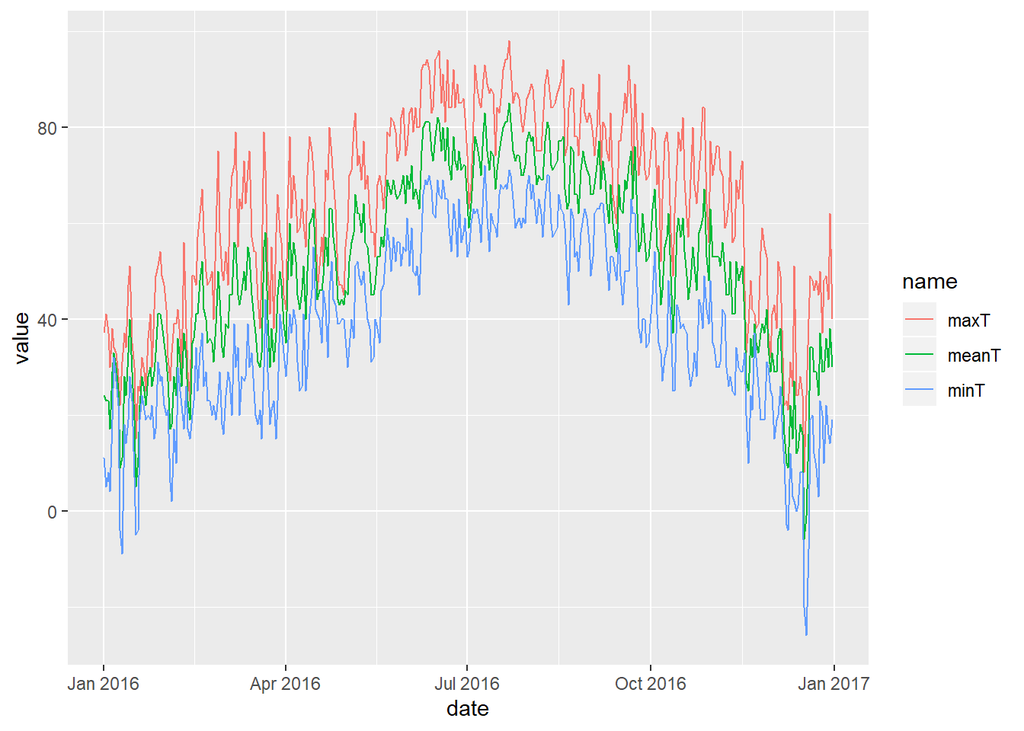

```r
# Plot temperatures by day
tdData %>%
    select(date, maxT, meanT, minT) %>%
    pivot_longer(-date) %>%
    ggplot(aes(x=date, y=value, group=name)) +
    geom_line(aes(color=name))
```

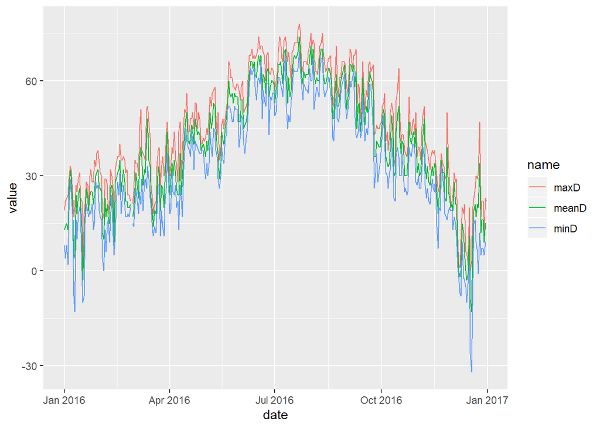

```r
# Plot dew points by day
tdData %>%
    select(date, maxD, meanD, minD) %>%
    pivot_longer(-date) %>%
    ggplot(aes(x=date, y=value, group=name)) +
    geom_line(aes(color=name))
```

```r
library(xts)
```

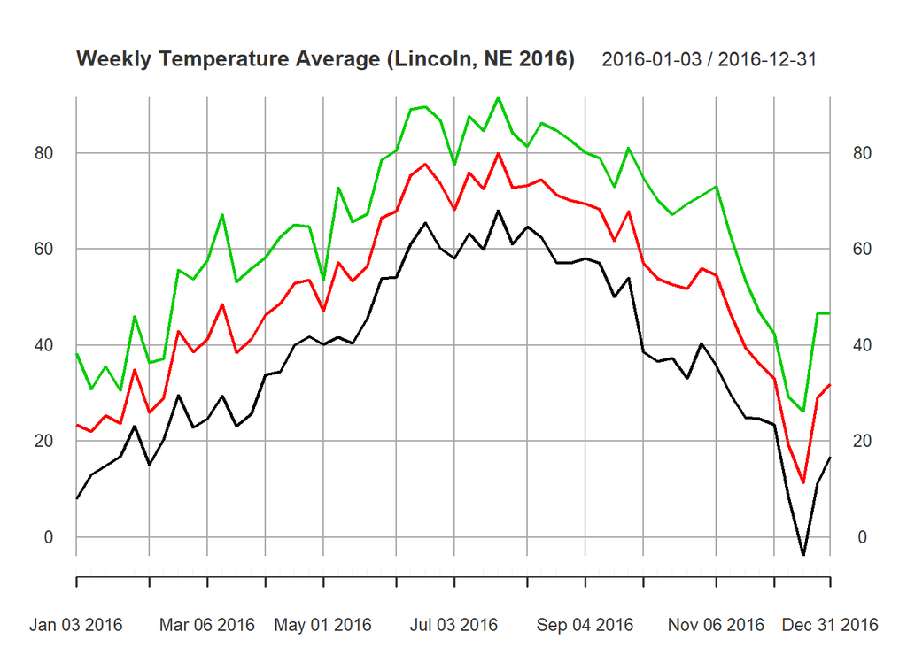

```r
# Create an XTS for temperature data
tdXTS <- xts(select(tdData, minT, meanT, maxT), order.by=tdData$date)

# Create and plot weekly and monthly averages
tdXTS %>%
    apply.weekly(FUN=mean, na.rm=TRUE) %>%
    plot(main="Weekly Temperature Average (Lincoln, NE 2016)")
```

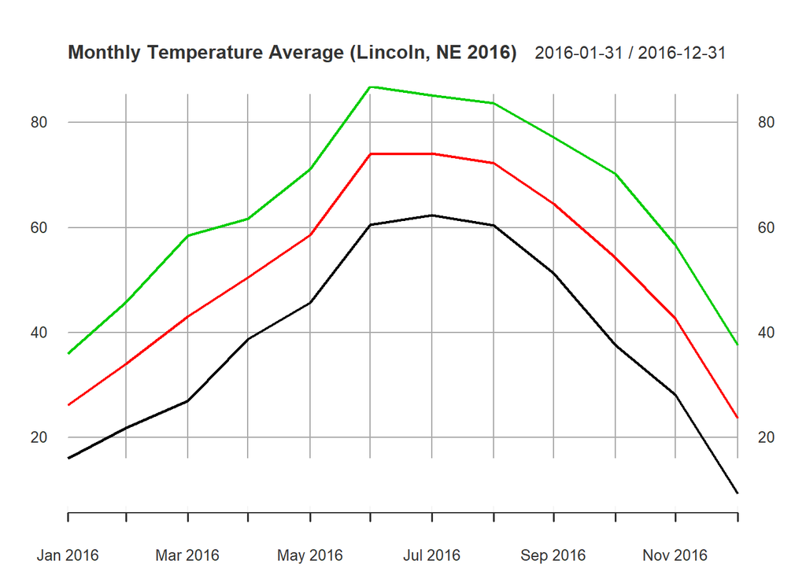

```r
tdXTS %>%
    apply.monthly(FUN=mean, na.rm=TRUE) %>%
    plot(main="Monthly Temperature Average (Lincoln, NE 2016)")
```

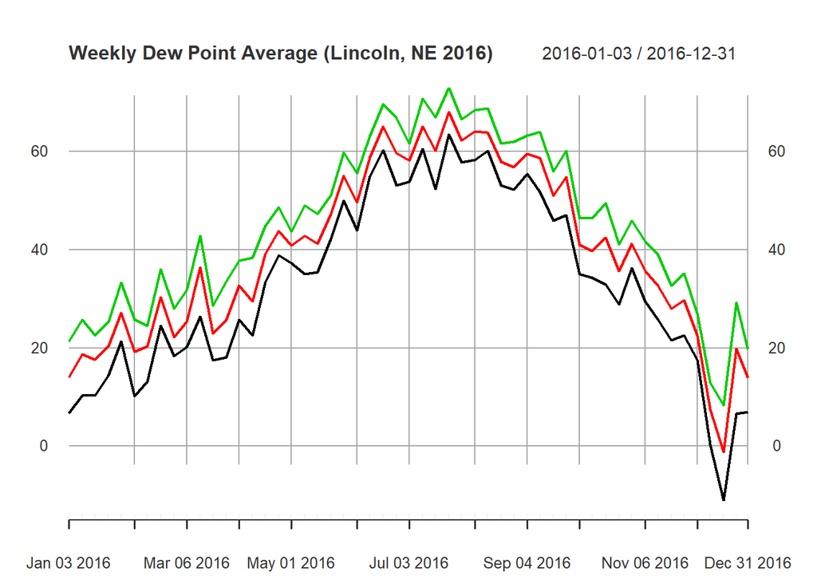

```r
# Create an XTS for dew-point data
tdXTS <- xts(select(tdData, minD, meanD, maxD), order.by=tdData$date)

# Create and plot weekly and monthly averages
tdXTS %>%
    apply.weekly(FUN=mean, na.rm=TRUE) %>%
    plot(main="Weekly Dew Point Average (Lincoln, NE 2016)")
```

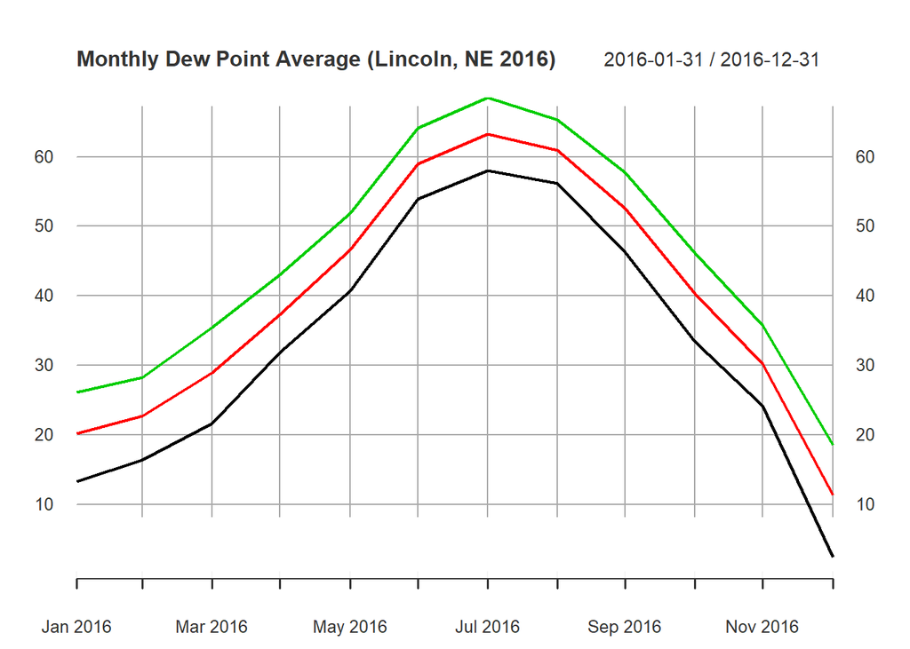

```r
tdXTS %>%
    apply.monthly(FUN=mean, na.rm=TRUE) %>%
    plot(main="Monthly Dew Point Average (Lincoln, NE 2016)")
```